# tarea2

María José Hernández de Santos

16/2/2022

**Tarea 2**

Elabora un documento de RMarkdown con tus respuestas. Envía y/o sube a una liga de github tu respuesta debes incluir al menos el archivo con extensión Rmd y opcionalmente el archivo html. Los comentarios a los problemas, códigos y sobre todo discusión de tus resultados deben ir como texto de RMarkdown

## 1. (15) Considera las siguientes cantidades discute y justifica qué tipo de distribución de probabilidad pueden tener las siguientes variables:

#### a. El número (talla) de calzado de adultos varones en México.

**Gaussiana**, ya que la mayoría de los adultos varones poseen un número de calzado que ronda al rededor del promedio, mientras que unos pocos tendrán una talla de calzado muy grande o muy pequeña.

#### b. La distribución de habitantes en asentamientos humanos de México.

*Distribución de cola larga, ya que hay pocas ciudades con muchos habitantes, mientras que la mayoría de las ciudades son medianas o pequeñas.*

3. La velocidad promedio de los automóviles en Bernardo Quintana a las 9 de la mañana en un día laborable.

**Poisson**, ya que BQ, al ser una vialidad importante, cruza casi todo querétaro. Habrá segmentos de BQ en los que los haya embotellamientos, mientras que habrá otras automovilistas vayan más rápido debido a que ese segmento de la vialidad no está despejado. Además, considerando que la gente es desesperada, suele acelerar en los tramitos libres.

d. La velocidad promedio de los automóviles en Bernardo Quintana a las 3 de la mañana.

*Logarítmica, ya que es casi un hecho de que a las tres de la mañana BQ está libre. Podría pensar también en que la urgencia de llegar a tu casa en la madrugada es mucha porque pues… está pegriloso.*

$5$ Supongamos que tenemos dos nodos (A,B) en una red. El nodo A y B tiene el mismo degree, pero el A tiene un coeficiente de clusterización de 1 y el nodo B un coeficiente bajo.Dibuja está situación y explica cuál sería una mejor diana si quieres eliminarlos y afectar a la red.

La mejor diana sería el nodo B, ya que de esta manera estamos alterando toda la conectividad de la red, en otras palabras, si quitas a B, estás logrando que los nodos cercanos a este pierdan conectividad con el resto.

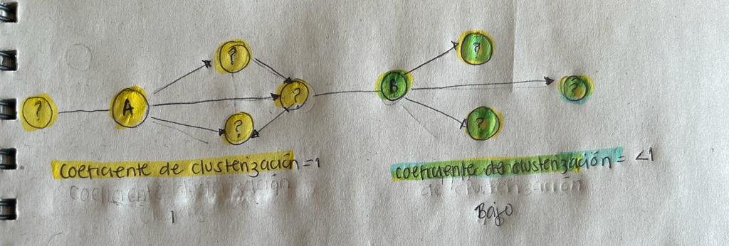

(olvidé marcar la linea que está en lapiz entre los signos de interrogación arriba y abajo del nodo a, pero se supone que así están conectados todos los nodos y por eso el coeficiente de clusterización es 1.

$40$ Elabora un programa en R que usando funciones calcule, a partir de una matriz de adyacencia (Sólo utiliza R base para resolver este problema)

a. Si la red es dirigida o no.

b. Si la red es pesada o no.

c. El degree de los nodos.

d. El histograma del degree.

```r
#primero debo crear la matriz de adyacencia
lamasmatriz<-matrix(nrow=3, ncol=3)
#ahí se creó una matriz vacía, ahora la voy a llenar
lamasmatriz[1,1]<-0
lamasmatriz[1,2]<-2
lamasmatriz[1,3]<-3
lamasmatriz[2,1]<-2
lamasmatriz[2,2]<-0
lamasmatriz[2,3]<-2
lamasmatriz[3,1]<-3
lamasmatriz[3,2]<-2
lamasmatriz[3,3]<-0
lamasmatriz
```

```
##      [,1] [,2] [,3]
## [1,]    0    2    3
## [2,]    2    0    2
## [3,]    3    2    0
```

#### la red es dirigida o no?

si una red es dirigida, M
$$ij$$
es distinto de M
$$ji$$
, mientras que si la red es dirigida, M
$$ij$$
es igual a M
$$ji$$
. En esta función que acabo de crear, apartir de una matriz, siendo i los valores de las columnas y j el de las filas, se comparan las coordenadas en ij y ji, de ser iguales, se trata de una red no dirigida, de ser distintas, se trata de una red dirigida.

```r
  directedornot<-function(matriz){
    for(i in 1:ncol(matriz)){
    for( j in 1:nrow(matriz)){
    if ((matriz)[i,j] != (matriz)[j,i]){
      print ("red dirigida")} else{print("red no dirigida")}
}
  }
   }

directedornot(lamasmatriz)
```

```
## [1] "red no dirigida"
## [1] "red no dirigida"
## [1] "red no dirigida"
## [1] "red no dirigida"
## [1] "red no dirigida"
## [1] "red no dirigida"
## [1] "red no dirigida"
## [1] "red no dirigida"
## [1] "red no dirigida"
```

```r
  #mi red es no dirigida
```

#### La matriz es pesada?

Una matriz es pesada cuando la conexión tiene un valor distinto de uno.

En este caso, si ij o ji son mayores que 1, se trata de una red pesada.

En la estructura de mi función, establezco que para un objeto matriz, y con ayuda de un ciclo for, dependiendo de que el valor de M
$$i,j$$
y M
$$j,i$$
cumpla ciertas condiciones, arroje si la red es pesada o no. Esto para todos los valores de i y j (1:ncol, 1:nrow).

Las condiciones están establecidadas con condicionales if, else if y else. Si la condición de que M
$$i,j$$
y M
$$j,i$$
sean mayores que 1, se imprimirá la frase “red pesada”; si son iguales a 1, se imprimirá la frase “Red no pesada”, y si son iguales a 0, se ignora por la carencia de conexión (en este caso la interacción del nodo consigo mismo)

```r
pesado<-function(matriz){
  for(i in 1:ncol(matriz)){
    for(j in 1:nrow(matriz)){
      if ((matriz)[i,j]>1){print("Red pesada")} else if ((matriz)[j,i]>1){print("Red pesada")} else if((matriz)[i,j]==0){print("-")} else if((matriz)[j,i]==0){print("")}
      else{print("red no pesada")}
    }
  }
}

pesado(lamasmatriz)
```

```
## [1] "-"
## [1] "Red pesada"
## [1] "Red pesada"
## [1] "Red pesada"
## [1] "-"
## [1] "Red pesada"
## [1] "Red pesada"
## [1] "Red pesada"
## [1] "-"
```

#### Degree de nodos

```r
di<-function(matriz){for(i in nrow(matriz)){ return(di<-c(sum(matriz[,i])))
}}
di(lamasmatriz)
```

```
## [1] 5
```

```r
#no sé qué hice mal:c
```

#### histograma del degree

```r
htgrm<-function(di){hist(di)}
htgrm<-lamasmatriz
#no me saleeee:c
```